# Risk Factor Analysis

## Outcome Variable

**Outcome Variable:** dead

## Predictor Variables

**Intervention Variable:** ever_wasted024

**Adjustment Set:**

- sex
- arm
- brthmon
- vagbrth
- hhwealth_quart
- W_mage
- W_mhtcm
- W_mwtkg
- W_mbmi
- W_meducyrs
- W_feducyrs
- W_nrooms
- W_parity
- impsan
- safeh20
- delta_vagbrth
- delta_hhwealth_quart
- delta_W_mage
- delta_W_mhtcm
- delta_W_mwtkg
- delta_W_mbmi
- delta_W_meducyrs
- delta_W_feducyrs
- delta_W_nrooms
- delta_W_parity
- delta_impsan
- delta_safeh20

## Stratifying Variables

The analysis was stratified on these variable(s):

- studyid
- country

## Data Summary

| studyid | country | ever_wasted024 | dead | n_cell | n | outcome_variable |
| --- | --- | --- | --- | --- | --- | --- |
| Burkina Faso Zn | BURKINA FASO | 0 | 0 | 5737 | 7166 | dead |
| Burkina Faso Zn | BURKINA FASO | 0 | 1 | 23 | 7166 | dead |
| Burkina Faso Zn | BURKINA FASO | 1 | 0 | 1390 | 7166 | dead |
| Burkina Faso Zn | BURKINA FASO | 1 | 1 | 16 | 7166 | dead |
| EE | PAKISTAN | 0 | 0 | 153 | 380 | dead |
| EE | PAKISTAN | 0 | 1 | 1 | 380 | dead |
| EE | PAKISTAN | 1 | 0 | 223 | 380 | dead |
| EE | PAKISTAN | 1 | 1 | 3 | 380 | dead |
| GMS-Nepal | NEPAL | 0 | 0 | 276 | 686 | dead |
| GMS-Nepal | NEPAL | 0 | 1 | 5 | 686 | dead |
| GMS-Nepal | NEPAL | 1 | 0 | 403 | 686 | dead |
| GMS-Nepal | NEPAL | 1 | 1 | 2 | 686 | dead |
| iLiNS-DOSE | MALAWI | 0 | 0 | 1660 | 1931 | dead |
| iLiNS-DOSE | MALAWI | 0 | 1 | 113 | 1931 | dead |
| iLiNS-DOSE | MALAWI | 1 | 0 | 143 | 1931 | dead |
| iLiNS-DOSE | MALAWI | 1 | 1 | 15 | 1931 | dead |
| iLiNS-DYAD-M | MALAWI | 0 | 0 | 1060 | 1201 | dead |
| iLiNS-DYAD-M | MALAWI | 0 | 1 | 31 | 1201 | dead |
| iLiNS-DYAD-M | MALAWI | 1 | 0 | 103 | 1201 | dead |
| iLiNS-DYAD-M | MALAWI | 1 | 1 | 7 | 1201 | dead |
| JiVitA-3 | BANGLADESH | 0 | 0 | 19607 | 26956 | dead |
| JiVitA-3 | BANGLADESH | 0 | 1 | 394 | 26956 | dead |
| JiVitA-3 | BANGLADESH | 1 | 0 | 6786 | 26956 | dead |
| JiVitA-3 | BANGLADESH | 1 | 1 | 169 | 26956 | dead |
| JiVitA-4 | BANGLADESH | 0 | 0 | 3724 | 5443 | dead |
| JiVitA-4 | BANGLADESH | 0 | 1 | 30 | 5443 | dead |
| JiVitA-4 | BANGLADESH | 1 | 0 | 1670 | 5443 | dead |
| JiVitA-4 | BANGLADESH | 1 | 1 | 19 | 5443 | dead |
| Keneba | GAMBIA | 0 | 0 | 1609 | 2920 | dead |
| Keneba | GAMBIA | 0 | 1 | 33 | 2920 | dead |
| Keneba | GAMBIA | 1 | 0 | 1249 | 2920 | dead |
| Keneba | GAMBIA | 1 | 1 | 29 | 2920 | dead |
| MAL-ED | BANGLADESH | 0 | 0 | 174 | 263 | dead |
| MAL-ED | BANGLADESH | 0 | 1 | 2 | 263 | dead |
| MAL-ED | BANGLADESH | 1 | 0 | 87 | 263 | dead |
| MAL-ED | BANGLADESH | 1 | 1 | 0 | 263 | dead |
| MAL-ED | INDIA | 0 | 0 | 130 | 251 | dead |
| MAL-ED | INDIA | 0 | 1 | 1 | 251 | dead |
| MAL-ED | INDIA | 1 | 0 | 119 | 251 | dead |
| MAL-ED | INDIA | 1 | 1 | 1 | 251 | dead |
| MAL-ED | PERU | 0 | 0 | 273 | 302 | dead |
| MAL-ED | PERU | 0 | 1 | 2 | 302 | dead |
| MAL-ED | PERU | 1 | 0 | 27 | 302 | dead |
| MAL-ED | PERU | 1 | 1 | 0 | 302 | dead |
| MAL-ED | SOUTH AFRICA | 0 | 0 | 248 | 312 | dead |
| MAL-ED | SOUTH AFRICA | 0 | 1 | 0 | 312 | dead |
| MAL-ED | SOUTH AFRICA | 1 | 0 | 64 | 312 | dead |
| MAL-ED | SOUTH AFRICA | 1 | 1 | 0 | 312 | dead |
| MAL-ED | TANZANIA, UNITED REPUBLIC OF | 0 | 0 | 222 | 261 | dead |
| MAL-ED | TANZANIA, UNITED REPUBLIC OF | 0 | 1 | 3 | 261 | dead |
| MAL-ED | TANZANIA, UNITED REPUBLIC OF | 1 | 0 | 36 | 261 | dead |
| MAL-ED | TANZANIA, UNITED REPUBLIC OF | 1 | 1 | 0 | 261 | dead |
| PROVIDE | BANGLADESH | 0 | 0 | 450 | 700 | dead |
| PROVIDE | BANGLADESH | 0 | 1 | 4 | 700 | dead |
| PROVIDE | BANGLADESH | 1 | 0 | 246 | 700 | dead |
| PROVIDE | BANGLADESH | 1 | 1 | 0 | 700 | dead |
| SAS-CompFeed | INDIA | 0 | 0 | 866 | 1513 | dead |
| SAS-CompFeed | INDIA | 0 | 1 | 19 | 1513 | dead |
| SAS-CompFeed | INDIA | 1 | 0 | 610 | 1513 | dead |
| SAS-CompFeed | INDIA | 1 | 1 | 18 | 1513 | dead |
| SAS-FoodSuppl | INDIA | 0 | 0 | 219 | 418 | dead |
| SAS-FoodSuppl | INDIA | 0 | 1 | 2 | 418 | dead |
| SAS-FoodSuppl | INDIA | 1 | 0 | 193 | 418 | dead |
| SAS-FoodSuppl | INDIA | 1 | 1 | 4 | 418 | dead |
| TanzaniaChild2 | TANZANIA, UNITED REPUBLIC OF | 0 | 0 | 1829 | 2396 | dead |
| TanzaniaChild2 | TANZANIA, UNITED REPUBLIC OF | 0 | 1 | 1 | 2396 | dead |
| TanzaniaChild2 | TANZANIA, UNITED REPUBLIC OF | 1 | 0 | 566 | 2396 | dead |
| TanzaniaChild2 | TANZANIA, UNITED REPUBLIC OF | 1 | 1 | 0 | 2396 | dead |
| VITAMIN-A | INDIA | 0 | 0 | 2556 | 3904 | dead |
| VITAMIN-A | INDIA | 0 | 1 | 35 | 3904 | dead |
| VITAMIN-A | INDIA | 1 | 0 | 1273 | 3904 | dead |
| VITAMIN-A | INDIA | 1 | 1 | 40 | 3904 | dead |
| ZVITAMBO | ZIMBABWE | 0 | 0 | 9963 | 13946 | dead |
| ZVITAMBO | ZIMBABWE | 0 | 1 | 682 | 13946 | dead |
| ZVITAMBO | ZIMBABWE | 1 | 0 | 2930 | 13946 | dead |
| ZVITAMBO | ZIMBABWE | 1 | 1 | 371 | 13946 | dead |

The following strata were considered:

- studyid: Burkina Faso Zn, country: BURKINA FASO
- studyid: EE, country: PAKISTAN
- studyid: GMS-Nepal, country: NEPAL
- studyid: iLiNS-DOSE, country: MALAWI
- studyid: iLiNS-DYAD-M, country: MALAWI
- studyid: JiVitA-3, country: BANGLADESH
- studyid: JiVitA-4, country: BANGLADESH
- studyid: Keneba, country: GAMBIA
- studyid: MAL-ED, country: BANGLADESH
- studyid: MAL-ED, country: INDIA
- studyid: MAL-ED, country: PERU
- studyid: MAL-ED, country: SOUTH AFRICA
- studyid: MAL-ED, country: TANZANIA, UNITED REPUBLIC OF
- studyid: PROVIDE, country: BANGLADESH
- studyid: SAS-CompFeed, country: INDIA
- studyid: SAS-FoodSuppl, country: INDIA
- studyid: TanzaniaChild2, country: TANZANIA, UNITED REPUBLIC OF
- studyid: VITAMIN-A, country: INDIA
- studyid: ZVITAMBO, country: ZIMBABWE

### Dropped Strata

Some strata were dropped due to rare outcomes:

- studyid: EE, country: PAKISTAN
- studyid: GMS-Nepal, country: NEPAL
- studyid: MAL-ED, country: BANGLADESH
- studyid: MAL-ED, country: INDIA
- studyid: MAL-ED, country: PERU
- studyid: MAL-ED, country: SOUTH AFRICA
- studyid: MAL-ED, country: TANZANIA, UNITED REPUBLIC OF
- studyid: PROVIDE, country: BANGLADESH
- studyid: SAS-FoodSuppl, country: INDIA
- studyid: TanzaniaChild2, country: TANZANIA, UNITED REPUBLIC OF

## Methods Detail

We’re interested in the causal parameters $E[Y_a]$ for all values of $a \in \mathcal{A}$. These parameters represent the mean outcome if, possibly contrary to fact, we intervened to set all units to have $A=a$. Under the randomization and positivity assumptions, these are identified by the statistical parameters $\psi_a=E_W[E_{Y|A,W}(Y|A=a,W)]$. In addition, we’re interested in the mean of $Y$, $E[Y]$ under no intervention (the observed mean). We will estimate these parameters by using SuperLearner to fit the relevant likelihood factors – $E_{Y|A,W}(Y|A=a,W)$ and $p(A=a|W)$, and then updating our likelihood fit using a joint TMLE.

For unadjusted analyses ($W=\{\}$), initial likelihoods were estimated using Lrnr_glm to estimate the simple $E(Y|A)$ and Lrnr_mean to estimate $p(A)$. For adjusted analyses, a small library containing Lrnr_glmnet, Lrnr_xgboost, and Lrnr_mean was used.

Having estimated these parameters, we will then use the delta method to estimate relative risks and attributable risks relative to a prespecified baseline level of $A$.

[output not shown]

[output not shown]

# Results Detail

## Results Plots

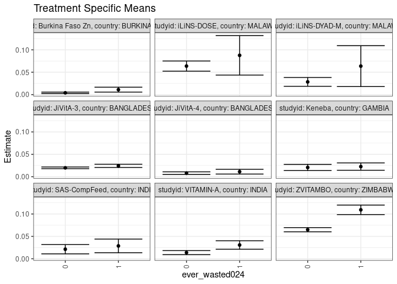

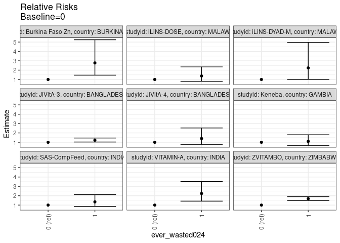

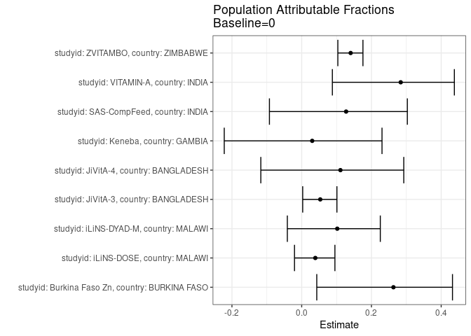

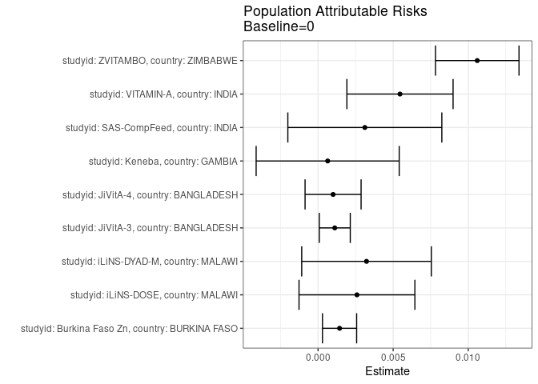

## Results Table

### Parameter: TSM

| studyid | country | intervention_level | baseline_level | estimate | ci_lower | ci_upper |
| --- | --- | --- | --- | --- | --- | --- |
| Burkina Faso Zn | BURKINA FASO | 0 | NA | 0.0040106 | 0.0023743 | 0.0056470 |
| Burkina Faso Zn | BURKINA FASO | 1 | NA | 0.0111084 | 0.0056480 | 0.0165688 |
| iLiNS-DOSE | MALAWI | 0 | NA | 0.0636986 | 0.0523239 | 0.0750732 |
| iLiNS-DOSE | MALAWI | 1 | NA | 0.0876968 | 0.0436556 | 0.1317379 |
| iLiNS-DYAD-M | MALAWI | 0 | NA | 0.0284143 | 0.0185509 | 0.0382777 |
| iLiNS-DYAD-M | MALAWI | 1 | NA | 0.0636364 | 0.0180004 | 0.1092724 |
| JiVitA-3 | BANGLADESH | 0 | NA | 0.0197750 | 0.0178739 | 0.0216761 |
| JiVitA-3 | BANGLADESH | 1 | NA | 0.0241848 | 0.0205174 | 0.0278521 |
| JiVitA-4 | BANGLADESH | 0 | NA | 0.0080026 | 0.0051647 | 0.0108405 |
| JiVitA-4 | BANGLADESH | 1 | NA | 0.0112265 | 0.0059382 | 0.0165148 |
| Keneba | GAMBIA | 0 | NA | 0.0205930 | 0.0136440 | 0.0275420 |
| Keneba | GAMBIA | 1 | NA | 0.0225885 | 0.0143999 | 0.0307771 |
| SAS-CompFeed | INDIA | 0 | NA | 0.0213401 | 0.0109557 | 0.0317245 |
| SAS-CompFeed | INDIA | 1 | NA | 0.0286852 | 0.0134274 | 0.0439431 |
| VITAMIN-A | INDIA | 0 | NA | 0.0137563 | 0.0092002 | 0.0183124 |
| VITAMIN-A | INDIA | 1 | NA | 0.0307536 | 0.0212869 | 0.0402204 |
| ZVITAMBO | ZIMBABWE | 0 | NA | 0.0649057 | 0.0602425 | 0.0695688 |
| ZVITAMBO | ZIMBABWE | 1 | NA | 0.1092602 | 0.0986145 | 0.1199058 |

### Parameter: E(Y)

| studyid | country | intervention_level | baseline_level | estimate | ci_lower | ci_upper |
| --- | --- | --- | --- | --- | --- | --- |
| Burkina Faso Zn | BURKINA FASO | NA | NA | 0.0054424 | 0.0037388 | 0.0071459 |
| iLiNS-DOSE | MALAWI | NA | NA | 0.0662869 | 0.0551877 | 0.0773861 |
| iLiNS-DYAD-M | MALAWI | NA | NA | 0.0316403 | 0.0217366 | 0.0415440 |
| JiVitA-3 | BANGLADESH | NA | NA | 0.0208859 | 0.0191395 | 0.0226323 |
| JiVitA-4 | BANGLADESH | NA | NA | 0.0090024 | 0.0064532 | 0.0115515 |
| Keneba | GAMBIA | NA | NA | 0.0212329 | 0.0160032 | 0.0264626 |
| SAS-CompFeed | INDIA | NA | NA | 0.0244547 | 0.0133604 | 0.0355490 |
| VITAMIN-A | INDIA | NA | NA | 0.0192111 | 0.0149047 | 0.0235174 |
| ZVITAMBO | ZIMBABWE | NA | NA | 0.0755055 | 0.0711204 | 0.0798906 |

### Parameter: RR

| studyid | country | intervention_level | baseline_level | estimate | ci_lower | ci_upper |
| --- | --- | --- | --- | --- | --- | --- |
| Burkina Faso Zn | BURKINA FASO | 0 | 0 | 1.000000 | 1.0000000 | 1.000000 |
| Burkina Faso Zn | BURKINA FASO | 1 | 0 | 2.769742 | 1.4622065 | 5.246503 |
| iLiNS-DOSE | MALAWI | 0 | 0 | 1.000000 | 1.0000000 | 1.000000 |
| iLiNS-DOSE | MALAWI | 1 | 0 | 1.376746 | 0.8080951 | 2.345553 |
| iLiNS-DYAD-M | MALAWI | 0 | 0 | 1.000000 | 1.0000000 | 1.000000 |
| iLiNS-DYAD-M | MALAWI | 1 | 0 | 2.239589 | 1.0096057 | 4.968039 |
| JiVitA-3 | BANGLADESH | 0 | 0 | 1.000000 | 1.0000000 | 1.000000 |
| JiVitA-3 | BANGLADESH | 1 | 0 | 1.222995 | 1.0281506 | 1.454764 |
| JiVitA-4 | BANGLADESH | 0 | 0 | 1.000000 | 1.0000000 | 1.000000 |
| JiVitA-4 | BANGLADESH | 1 | 0 | 1.402857 | 0.7772685 | 2.531953 |
| Keneba | GAMBIA | 0 | 0 | 1.000000 | 1.0000000 | 1.000000 |
| Keneba | GAMBIA | 1 | 0 | 1.096902 | 0.6682963 | 1.800391 |
| SAS-CompFeed | INDIA | 0 | 0 | 1.000000 | 1.0000000 | 1.000000 |
| SAS-CompFeed | INDIA | 1 | 0 | 1.344195 | 0.8532316 | 2.117667 |
| VITAMIN-A | INDIA | 0 | 0 | 1.000000 | 1.0000000 | 1.000000 |
| VITAMIN-A | INDIA | 1 | 0 | 2.235603 | 1.4225139 | 3.513444 |
| ZVITAMBO | ZIMBABWE | 0 | 0 | 1.000000 | 1.0000000 | 1.000000 |
| ZVITAMBO | ZIMBABWE | 1 | 0 | 1.683369 | 1.4925331 | 1.898605 |

### Parameter: PAR

| studyid | country | intervention_level | baseline_level | estimate | ci_lower | ci_upper |
| --- | --- | --- | --- | --- | --- | --- |
| Burkina Faso Zn | BURKINA FASO | 0 | NA | 0.0014317 | 0.0002936 | 0.0025698 |
| iLiNS-DOSE | MALAWI | 0 | NA | 0.0025883 | -0.0012692 | 0.0064459 |
| iLiNS-DYAD-M | MALAWI | 0 | NA | 0.0032260 | -0.0010888 | 0.0075408 |
| JiVitA-3 | BANGLADESH | 0 | NA | 0.0011109 | 0.0000780 | 0.0021437 |
| JiVitA-4 | BANGLADESH | 0 | NA | 0.0009998 | -0.0008656 | 0.0028652 |
| Keneba | GAMBIA | 0 | NA | 0.0006399 | -0.0041234 | 0.0054031 |
| SAS-CompFeed | INDIA | 0 | NA | 0.0031146 | -0.0020129 | 0.0082421 |
| VITAMIN-A | INDIA | 0 | NA | 0.0054548 | 0.0019191 | 0.0089905 |
| ZVITAMBO | ZIMBABWE | 0 | NA | 0.0105999 | 0.0078190 | 0.0133808 |

### Parameter: PAF

| studyid | country | intervention_level | baseline_level | estimate | ci_lower | ci_upper |
| --- | --- | --- | --- | --- | --- | --- |
| Burkina Faso Zn | BURKINA FASO | 0 | NA | 0.2630717 | 0.0432267 | 0.4324012 |
| iLiNS-DOSE | MALAWI | 0 | NA | 0.0390474 | -0.0206302 | 0.0952355 |
| iLiNS-DYAD-M | MALAWI | 0 | NA | 0.1019586 | -0.0411726 | 0.2254134 |
| JiVitA-3 | BANGLADESH | 0 | NA | 0.0531871 | 0.0028650 | 0.1009696 |
| JiVitA-4 | BANGLADESH | 0 | NA | 0.1110593 | -0.1172355 | 0.2927046 |
| Keneba | GAMBIA | 0 | NA | 0.0301353 | -0.2220908 | 0.2303047 |
| SAS-CompFeed | INDIA | 0 | NA | 0.1273633 | -0.0925175 | 0.3029907 |
| VITAMIN-A | INDIA | 0 | NA | 0.2839384 | 0.0879577 | 0.4378065 |
| ZVITAMBO | ZIMBABWE | 0 | NA | 0.1403852 | 0.1036429 | 0.1756215 |